# STAT $1210$

Chapter $9$ Homework: Essential Probability Rules

Fall $2026$

### Question 1: Sea Turtle Hatchlings and Empirical Probability

A coastal wildlife team monitors $800$ newly hatched sea turtles as they travel from their nests toward the ocean. Of these hatchlings, $684$ successfully reach the water. The remaining hatchlings become disoriented, encounter obstacles or are intercepted by predators before reaching the shoreline. The figures are illustrative.

1. What is the random phenomenon and what are its two possible outcomes for one hatchling?
2. Use the observations to estimate the probability that a hatchling successfully reaches the ocean.
3. Estimate the probability that a hatchling does not reach the ocean.
4. If the same success rate applies to another $2000$ hatchlings under similar conditions, how many would be expected not to reach the ocean?
5. Does the answer to Part $4$ guarantee that exactly this many hatchlings will fail to reach the ocean? Explain using the frequentist interpretation of probability.

**Show solution**

1. The random phenomenon is whether one newly hatched sea turtle successfully reaches the ocean. The two possible outcomes are reaching the ocean and not reaching the ocean.
2. The empirical probability of reaching the ocean is
   $$\widehat{P}(\text{reaches the ocean}) =
   \frac{684}{800} = 0.855$$

   Therefore, the estimated probability is $0.855$ or $85.5%$.
3. Using the complement rule
   $$\widehat{P}(\text{does not reach the ocean}) =
   1-0.855 = 0.145$$

   Therefore the estimated probability is $0.145$, or $14.5%$.
4. The expected number is
   $$2000(0.145)=290$$

   Approximately $290$ hatchlings would be expected not to reach the ocean.
5. No. Probability describes long-run relative frequency, not the exact outcome of one future group. The observed number could be greater or less than $290$. However, across many hatchlings experiencing similar conditions, the proportion that does not reach the ocean should tend to remain near $0.145$.

### Question 2: Recovery Following Veterinary Procedures

A veterinary hospital classifies each animal’s recovery following a routine procedure into exactly one of three categories. The following probability model is based on the hospital’s historical records.

| Recovery outcome | Routine same-day recovery | Extended observation | Overnight hospitalization |
| --- | --- | --- | --- |
| Probability | $0.78$ | $0.17$ | $p$ |

1. Why are the three outcomes disjoint?
2. Calculate the missing probability $p$.
3. What is the probability that an animal requires either extended observation or overnight hospitalization?
4. Use the complement rule to verify the answer to Part $3$.
5. Among $600$ similar procedures, how many animals would be expected to require overnight hospitalization?

**Show solution**

1. The outcomes are disjoint because each recovery is assigned to exactly one category. An animal cannot simultaneously have a routine same-day recovery and require overnight hospitalization in this model.
2. The probabilities in the complete sample space must sum to $1$.
   $$0.78+0.17+p=1$$
   Therefore
   $$p = 1-0.95 = 0.05$$
3. Because the two outcomes are disjoint
   $$P(\text{extended or
   overnight})=0.17+0.05=0.22$$
4. The complement of requiring additional monitoring is routine same-day recovery. Therefore
   $$P(\text{extended or
   overnight})=1-0.78=0.22$$
5. The expected number is
   $$600(0.05)=30$$

   Approximately $30$ animals would be expected to require overnight hospitalization.

### Question 3: Wildlife Camera Trap Detections

A wildlife survey classifies the primary animal in each independent camera-triggered image into one of four categories.

| Animal category | White-tailed deer | Red fox | Raccoon | Other mammal |
| --- | --- | --- | --- | --- |
| Probability | $0.46$ | $0.18$ | $0.24$ | $0.12$ |

1. Verify that this is a valid probability model.
2. What is the probability that an image contains either a red fox or a raccoon?
3. What is the probability that an image does not contain a white-tailed deer?
4. Show that Parts $2$ and $3$ represent different events.
5. Among $1500$ camera-triggered images, how many would be expected to contain an animal from the “other mammal” category?

**Show solution**

1. Every probability is between $0$ and $1$ and
   $$0.46+0.18+0.24+0.12=1$$
   Therefore, the model is valid.
2. The animal categories are disjoint, so
   $$P(\text{fox or raccoon})=0.18+0.24=0.42$$
3. Using the complement rule
   $$P(\text{not
   deer})=1-0.46=0.54$$
4. The event “fox or raccoon” contains only two categories and has probability $0.42$. The event “not deer” also includes the other mammal category, so
   $$P(\text{not deer})=0.18+0.24+0.12=0.54$$
5. The expected number is
   $$1500(0.12)=180$$
   Approximately $180$ images would be expected to contain another mammal.

### Question 4: Radioactive Decay

A radioactive isotope is observed over a period equal to one half-life. The theoretical probability that an individual nucleus decays during this period is $0.50$. In one laboratory trial, $4937$ of $10000$ observed nuclei decay.

1. Calculate the empirical probability of decay in the laboratory trial.
2. Calculate the difference between the empirical probability and the theoretical probability.
3. If $60000$ nuclei are observed during one half-life, how many decays would be expected according to the theoretical model?
4. Must exactly half of the $60000$ nuclei decay? Explain.
5. According to the law of large numbers, what should happen to the observed proportion of decays as the number of observed nuclei becomes very large?

**Show solution**

1. The empirical probability is
   $$\widehat{P}(\text{decay})=\frac{4937}{10000}=0.4937$$
2. The difference is
   $$0.4937-0.5000=-0.0063$$
   The observed proportion is $0.0063$, or $0.63$ percentage points, below the theoretical probability.
3. The expected number of decays is
   $$60000(0.50)=30000$$
4. No. The value $30000$ is the long-run expected count. Random variation can produce a count above or below this value in a particular trial.
5. The observed proportion should tend to approach $0.50$ as the number of nuclei increases. It is not required to equal $0.50$ exactly at any finite sample size.

### Question 5: Fledgling Success in Songbird Nests

Let $X$ be the number of chicks that successfully leave a randomly selected nest of a particular songbird species. A long-term monitoring program proposes the following discrete probability model.

| Number fledged, $X$ | $0$ | $1$ | $2$ | $3$ | $4$ |
| --- | --- | --- | --- | --- | --- |
| Probability | $0.10$ | $0.18$ | $0.32$ | $0.27$ | $p$ |

1. Calculate the missing probability $p$.
2. Calculate $P(X\geq2)$.
3. Calculate $P(X>2)$.
4. Calculate $P(X\leq1)$ using both direct addition and the complement rule.
5. Explain why $P(X\geq2)$ and $P(X>2)$ are not equal.

**Show solution**

1. The probabilities must sum to $1$.
   $$p=1-(0.10+0.18+0.32+0.27)=1-0.87=0.13$$
2. At least two fledglings means $X=2$, $3$ or $4$.
   $$P(X\geq2)=0.32+0.27+0.13=0.72$$
3. More than two fledglings means $X=3$ or $4$.
   $$P(X>2)=0.27+0.13=0.40$$
4. Using direct addition
   $$P(X\leq1)=0.10+0.18=0.28$$

   Using the complement rule
   $$P(X\leq1)=1-P(X\geq2)=1-0.72=0.28$$
5. The event $X\geq2$ includes nests with exactly $2$ fledglings, whereas $X>2$ excludes them. The difference between the probabilities is $P(X=2)=0.32$.

### Question 6: Timing Error in a Physics Experiment

A sensor used in a physics experiment has a calibration error $Y$ that is uniformly distributed between $-0.4$ and $0.4$ microseconds. Thus, every interval of the same width within this range has the same probability.

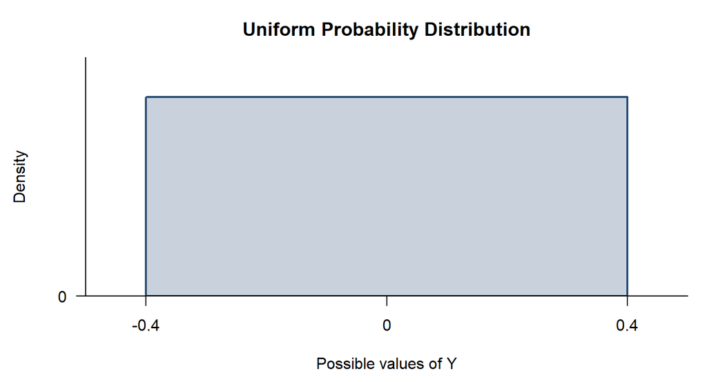

1. Is $Y$ discrete or continuous? What is the height of the density? What is the total width of its possible range?
2. Calculate $P(-0.1\leq Y\leq0.2)$.
3. Calculate $P(Y<-0.25\text{ or }Y>0.30)$.
4. What is $P(Y=0)$? Explain.
5. Calculate $P(Y\leq0.2)$ and explain why it equals $P(Y<0.2)$.

**Show solution**

For this uniform distribution, the density curve is a rectangle. Probabilities are found using areas under the density curve.
$$P(\text{interval})=\text{area of the
corresponding rectangle}=\text{width}\times\text{height}$$

#### 1. Type of variable, total width and density height

The variable $Y$ is continuous because it can take any value in the interval from $-0.4$ to $0.4$ microseconds. The total width of the distribution is
$$0.4-(-0.4)=0.8\text{
microseconds}$$
The total area under every probability density curve must equal $1$. Let $h$ represent the height of the uniform density. The density curve is a rectangle, so

$$\text{area}=\text{width}\times\text{height}$$

Therefore
$$1=(0.8)h$$
and hence
$$h=\frac{1}{0.8}=1.25$$
So the density has a constant height of $1.25$ per microsecond.

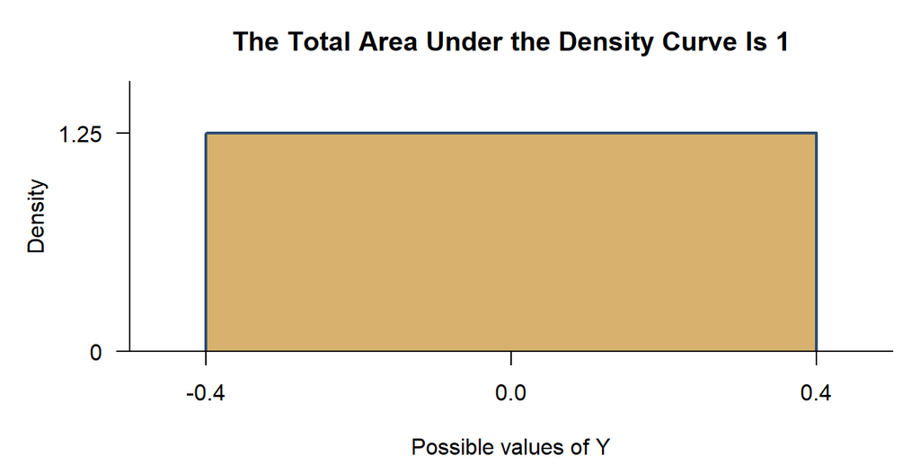

The area of the displayed rectangle is
$$(0.8)(1.25)=1$$

#### 2. Calculating $P(-0.1\leq Y\leq0.2)$

The required probability is the shaded rectangular area between $-0.1$ and $0.2$.

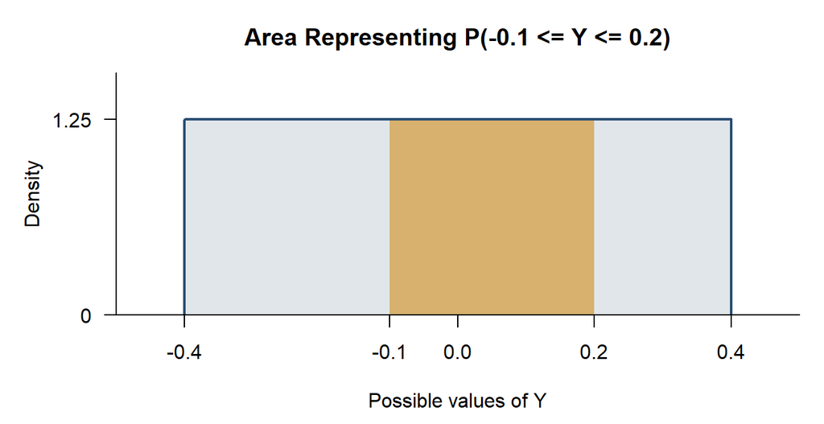

The width of the shaded rectangle is
$$0.2-(-0.1)=0.3$$

Its height is $1.25$. Therefore
$$\begin{aligned}
P(-0.1\leq Y\leq0.2)
&=\text{width}\times\text{height}\\
&=(0.3)(1.25)\\
&=0.375
\end{aligned}$$

Thus, the probability is $0.375$ or $37.5\%$.

#### 3. Calculating $P(Y<-0.25\text{ or }Y>0.30)$

The event contains two separate shaded rectangles: one to the left of $-0.25$ and one to the right of $0.30$.

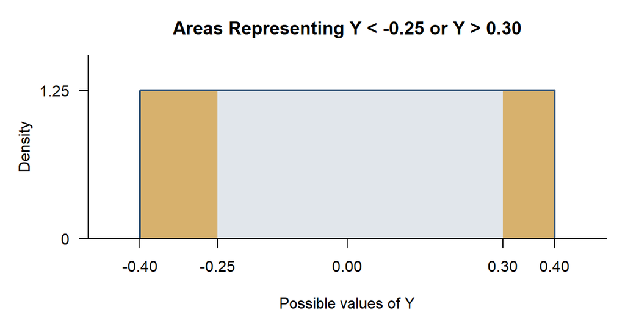

The width of the left rectangle is
$$-0.25-(-0.4)=0.15$$

Its area is
$$(0.15)(1.25)=0.1875$$

The width of the right rectangle is
$$0.4-0.30=0.10$$

Its area is
$$(0.10)(1.25)=0.125$$

Because the two regions do not overlap, their areas can be added:
$$\begin{aligned}
P(Y<-0.25\text{ or }Y>0.30)
&=0.1875+0.125\\
&=0.3125
\end{aligned}$$

Thus, the probability is $0.3125$ or $31.25\%$.

#### 4. Calculating $P(Y=0)$

The event $Y=0$ consists of only one point.

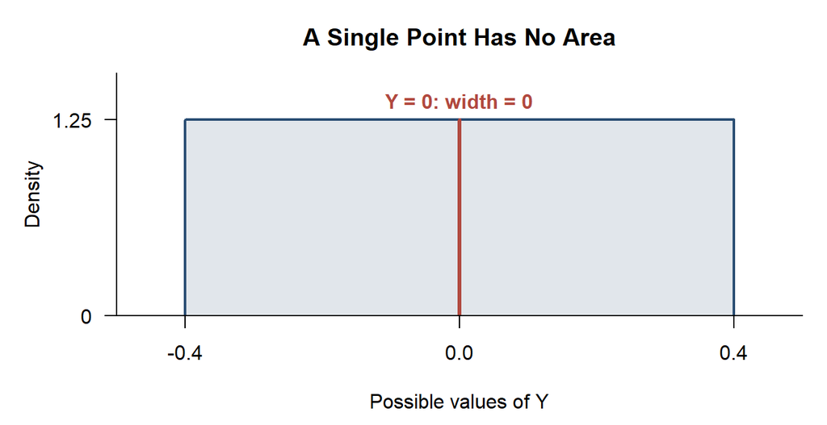

Although the vertical line has height $1.25$, it has width $0$. Therefore, its area is

$$\begin{aligned}
P(Y=0)
&=\text{width}\times\text{height}\\
&=(0)(1.25)\\
&=0
\end{aligned}$$

A single exact value has probability $0$ for a continuous random variable.

#### 5. Calculating $P(Y\leq0.2)$

The required probability is the area from the lower boundary, $-0.4$, to $0.2$.

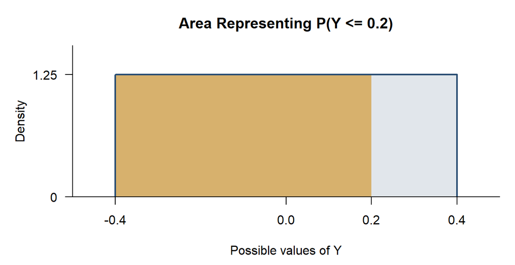

The width of the shaded rectangle is
$$0.2-(-0.4)=0.6$$

Therefore
$$\begin{aligned}
P(Y\leq0.2)
&=\text{width}\times\text{height}\\
&=(0.6)(1.25)\\
&=0.75
\end{aligned}$$

Thus
$$P(Y\leq0.2)=0.75$$

The only difference between $Y\leq0.2$ and $Y<0.2$ is the single endpoint $Y=0.2$. That point has width $0$ and therefore contributes no area.
$$P(Y=0.2)=(0)(1.25)=0$$

Consequently
$$P(Y\leq0.2)=P(Y<0.2)=0.75$$

### Question 7: Lobster Carapace Lengths

A marine biologist uses a continuous density model for the carapace length $L$ of adult lobsters in a study region. The model assigns the following areas to three length intervals.

| Carapace-length interval | Area under the density curve |
| --- | --- |
| Less than $80$ mm | $0.18$ |
| From $80$ mm through $100$ mm | $0.52$ |
| Greater than $100$ mm | $0.30$ |

1. Verify that the three regions form a complete probability model.
2. Calculate $P(L\geq80)$.
3. Calculate the probability that a lobster has a carapace length outside the interval from $80$ mm through $100$ mm.
4. What is $P(L=100)$? Explain.
5. Compare $P(80\leq L\leq100)$ with $P(80<L<100)$.
6. Among $600$ randomly selected adult lobsters, how many would be expected to have carapace lengths greater than $100$ mm?

**Show solution**

1. The areas are nonnegative and
   $$0.18+0.52+0.30=1$$
   Therefore, the three regions cover the complete continuous distribution.
2. Using the complement rule
   $$P(L\geq80)=1-P(L<80)=1-0.18=0.82$$
3. The two outside regions are disjoint, so
   $$P(L<80\text{ or
   }L>100)=0.18+0.30=0.48$$
4. Carapace length is continuous, so the probability of one exact value is
   $$P(L=100)=0$$
5. The endpoints each have probability $0$. Therefore
   $$P(80\leq
   L\leq100)=P(80<L<100)=0.52$$
6. The expected number is
   $$600(0.30)=180$$
   Approximately $180$ lobsters would be expected to have carapace lengths greater than $100$ mm.

### Question 8: Fledglings Produced by an Eagle Nest

Let $X$ be the number of young eagles that successfully leave a randomly selected monitored nest during one breeding season. An illustrative long-run probability model is shown below.

| Number of fledglings, $X$ | $0$ | $1$ | $2$ | $3$ |
| --- | --- | --- | --- | --- |
| Probability | $0.20$ | $0.45$ | $0.30$ | $0.05$ |

1. Verify that the table is a valid probability distribution.
2. Calculate the mean (expected value) $\mu=E(X)$.
3. Calculate the variance

$$\sigma^2=\sum(x_i-\mu)^2P(X=x_i)$$

4. Calculate the standard deviation $\sigma$.
5. Interpret the expected value. Why does an expected value of $1.2$ not mean that one nest can produce exactly $1.2$ fledglings?

**Show solution**

1. All probabilities are between $0$ and $1$ and
   $$0.20+0.45+0.30+0.05=1$$
2. The expected value is
   $$\begin{aligned}
   \mu
   &=(0)(0.20)+(1)(0.45)+(2)(0.30)+(3)(0.05)\\
   &=0+0.45+0.60+0.15\\
   &=1.20.
   \end{aligned}$$
3. The variance is
   $$\begin{aligned}
   \sigma^2
   &=(0-1.2)^2(0.20)+(1-1.2)^2(0.45)\\
   &\quad +(2-1.2)^2(0.30)+(3-1.2)^2(0.05)\\
   &=(1.44)(0.20)+(0.04)(0.45)\\
   &\quad +(0.64)(0.30)+(3.24)(0.05)\\
   &=0.288+0.018+0.192+0.162\\
   &=0.660.
   \end{aligned}$$
4. The standard deviation is
   $$\sigma=\sqrt{0.660}\approx0.812$$
5. Across a large number of monitored nests, the average number of fledglings per nest would tend toward $1.2$. A single nest can produce only one of the listed whole-number outcomes. The expected value is a long-run average, not a possible outcome for one nest.

### Question 9: Expected Payout from a Pet Insurance Policy

An insurer uses the following simplified model for the total veterinary reimbursement $X$ paid on one policy during one year. The categories represent possible annual payout levels, not the amount of an individual veterinary bill.

| Annual payout, $X$ | $\$0$ | $\$250$ | $\$800$ | $\$2500$ |
| --- | --- | --- | --- | --- |
| Probability | $0.78$ | $0.12$ | $0.07$ | $0.03$ |

1. Calculate the probability that the insurer makes a positive payout.
2. Calculate the expected annual payout $E(X)$ for one policy.
3. Calculate the variance and standard deviation of the annual payout.
4. For a portfolio of $5000$ similar policies, calculate the expected total annual payout.
5. Explain why a sustainable premium would generally need to exceed the expected payout calculated in Part $2$.

**Show solution**

1. Using the complement rule
   $$P(X>0)=1-P(X=0)=1-0.78=0.22$$
2. The expected payout is
   $$\begin{aligned}
   \mu=E(X)
   &=(0)(0.78)+(250)(0.12)\\
   &\quad +(800)(0.07)+(2500)(0.03)\\
   &=0+30+56+75\\
   &=\$161.
   \end{aligned}$$
3. Using $\mu=161$, the variance is
   $$\begin{aligned}
   \sigma^2
   &=(0-161)^2(0.78)+(250-161)^2(0.12)\\
   &\quad +(800-161)^2(0.07)+(2500-161)^2(0.03)\\
   &=213{,}879.
   \end{aligned}$$

   Therefore
   $$\sigma=\sqrt{213{,}879}\approx\$462.47$$
   The standard deviation is larger than the mean because most policies have no payout, while a small proportion have much larger payouts.
4. The expected total payout is
   $$5000(\$161)=\$805000$$
5. The expected payout covers only expected claim costs. A premium must also account for administration, claim processing, reserves, uncertainty, taxes and other operating expenses. The expected value is not automatically an appropriate final premium.

### Question 10: Risk and Odds of a Veterinary Complication

A veterinary hospital reviews $2400$ similar procedures and finds that $72$ animals experienced a minor post-procedure complication. The remaining animals did not experience the complication.

1. Estimate the risk, or probability, of the complication.
2. Estimate the probability that an animal does not experience the complication.
3. Calculate the odds of the complication as both a decimal and an event-to-non-event ratio.
4. If the same estimated risk applies to $10000$ future procedures, how many complications would be expected?
5. Explain why the numerical values of the risk and odds are close in this example but are not identical.

### Question 11: Converting Insurance Odds to Probability

An insurer reports that the annual odds of a weather-related water-damage claim in Region A are $1:24$. This notation means one claim occurrence for every $24$ non-occurrences. In Region B, the annual risk of the same type of claim is estimated to be $0.06$.

1. Convert the odds in Region A to a probability.
2. What is the probability that a policy in Region A does not produce such a claim during the year?
3. Among $12500$ similar policies in Region A, how many claims would be expected?
4. Convert the risk in Region B to decimal odds and to an event-to-non-event ratio.
5. Compare the two regions using probabilities. What is the difference in percentage points, and how many times as large is the Region B risk?

**Show solution**

1. Odds of $1:24$ correspond to decimal odds of $1/24$. Using
   $$p=\frac{\text{odds}}{1+\text{odds}}$$
   we obtain
   $$p=\frac{1/24}{1+1/24}=\frac{1/24}{25/24}=\frac{1}{25}=0.04$$
2. The complement is
   $$1-0.04=0.96$$
3. The expected number of claims is
   $$12500(0.04)=500$$
4. For Region B
   $$\text{odds}=\frac{0.06}{1-0.06}=\frac{0.06}{0.94}\approx0.06383$$
   The odds ratio is
   $$0.06:0.94=6:94=3:47$$
5. The risks are $4\%$ in Region A and $6\%$ in Region B. The difference is
   $$6\%-4\%=2$$
   percentage points. The ratio is
   $$\frac{0.06}{0.04}=1.5$$

   Therefore, the estimated risk in Region B is $1.5$ times the estimated risk in Region A.

### Question 12: Treatment Requirements for Rehabilitated Birds

A wildlife rehabilitation centre records the number of veterinary treatments $X$ required by a randomly admitted injured bird before it can be released or transferred. A simplified probability model is shown below.

| Number of treatments, $X$ | $0$ | $1$ | $2$ | $3$ | $4$ |
| --- | --- | --- | --- | --- | --- |
| Probability | $0.15$ | $0.30$ | $k$ | $0.20$ | $0.10$ |

1. Calculate the missing probability $k$.
2. Calculate the probability and the odds that a bird requires at least $2$ treatments.
3. Calculate the expected number of treatments, $\mu=E(X)$.
4. Calculate the variance and standard deviation of $X$.
5. If the centre admits $750$ birds under similar conditions, what is the expected total number of treatments?
6. Interpret the expected value and standard deviation in context.

**Show solution**

1. The probabilities must sum to $1$.
   $$k=1-(0.15+0.30+0.20+0.10)=0.25$$
2. The probability of at least $2$ treatments is
   $$P(X\geq2)=0.25+0.20+0.10=0.55$$
   The complement has probability $0.45$ so the odds are
   $$\frac{0.55}{0.45}=\frac{11}{9}\approx1.222$$

   As an event-to-non-event ratio, the odds are $11:9$.
3. The expected value is
   $$\begin{aligned}
   \mu
   &=(0)(0.15)+(1)(0.30)+(2)(0.25)\\
   &\quad +(3)(0.20)+(4)(0.10)\\
   &=0+0.30+0.50+0.60+0.40\\
   &=1.80.
   \end{aligned}$$
4. The variance is
   $$\begin{aligned}
   \sigma^2
   &=(0-1.8)^2(0.15)+(1-1.8)^2(0.30)\\
   &\quad +(2-1.8)^2(0.25)+(3-1.8)^2(0.20)\\
   &\quad +(4-1.8)^2(0.10)\\
   &=(3.24)(0.15)+(0.64)(0.30)+(0.04)(0.25)\\
   &\quad +(1.44)(0.20)+(4.84)(0.10)\\
   &=0.486+0.192+0.010+0.288+0.484\\
   &=1.460.
   \end{aligned}$$

   Therefore
   $$\sigma=\sqrt{1.460}\approx1.208$$
5. The expected total is
   $$750(1.8)=1350$$
   treatments.
6. Across many admitted birds, the centre would expect an average of $1.8$ treatments per bird. Individual birds require only whole numbers of treatments. The standard deviation of approximately $1.21$ treatments describes the typical distance of an individual bird’s treatment count from the long-run mean.